# Data wrangling

2019-04-24

## References

https://r4ds.had.co.nz/transform.html

https://moderndive.com/4-wrangling.html

## Tidyverse

[figure not shown]

## Prerequisites

```r
# install.packages("tidyverse")
library(tidyverse)

# install.packages(c("nycflights13", "tidyverse"))

library(tidyverse)
library(nycflights13)
```

## nycflights13

Contains all flights departed from NYC in 2013.

```r
head(flights)
```

```
## # A tibble: 6 x 19
##    year month   day dep_time sched_dep_time dep_delay arr_time
##   <int> <int> <int>    <int>          <int>     <dbl>    <int>
## 1  2013     1     1      517            515         2      830
## 2  2013     1     1      533            529         4      850
## 3  2013     1     1      542            540         2      923
## 4  2013     1     1      544            545        -1     1004
## 5  2013     1     1      554            600        -6      812
## 6  2013     1     1      554            558        -4      740
## # ... with 12 more variables: sched_arr_time <int>, arr_delay <dbl>,
## #   carrier <chr>, flight <int>, tailnum <chr>, origin <chr>, dest <chr>,
## #   air_time <dbl>, distance <dbl>, hour <dbl>, minute <dbl>,
## #   time_hour <dttm>
```

## Types of data

- `int` stands for integers
- `dbl` stands for doubles or real numbers
- `chr` stands for character vectors, or strings
- `dttm` stands for date-times
- `lgl` stands for logical vectors
- `fctr` stands for factors
- `date` stands for dates

## `dplyr` basics

- Pick observations by their values (`filter()`).
- Reorder the rows (`arrange()`).
- Pick variables by their names (`select()`).
- Create new variables with functions of existing variables (`mutate()`).
- Collapse many values down to a single summary (`summarise()`).

## Filter rows with `filter()`

```r
filter(flights, month == 1, day == 1)

# if you want to save

jan1 <- filter(flights, month == 1, day ==1)

# with the parenthesis you can also show the result
(dec25 <- filter(flights, month == 12, day == 25))
```

## Standard logical operators

- `>`
- `>=`
- `<`
- `<=`
- `!=` (not equal)
- `==` (equal)

## Difference between `=` and `==`

```r
filter(flights, month = 1)
```

```
#> Error: `month` (`month = 1`) must not be named, do you need `==`?
```

## Logical operators

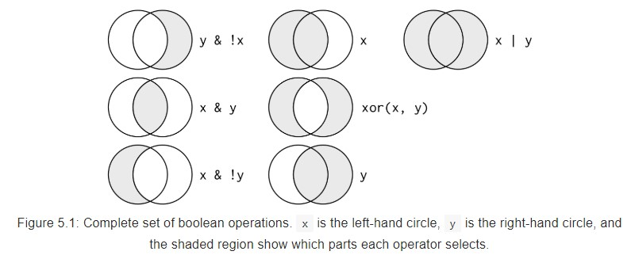

## Logical operators

You can combine multiple arguments to `filter()`

- `&` is “and”
- `|` is “or”
- `!` is “not”

## Demonstration

Find all flights that departed in November or December

```r
filter(flights, month == 11 | month == 12)

# or

filter(flights, month %in% c(11, 12))
```

Find flights that weren’t delayed (on arrival or departure) by more than two hours

```r
filter(flights, !(arr_delay > 120 | dep_delay > 120))
filter(flights, arr_delay <= 120, dep_delay <= 120)
```

## Exercises

Find all flights that

1. Had an arrival delay of two or more hours
2. Flew to Houston (IAH or HOU)
3. Were operated by United, American, or Delta
4. Departed in summer (July, August, and September)
5. Arrived more than two hours late, but didn’t leave late
6. Were delayed by at least an hour, but made up over 30 minutes in flight
7. Departed between midnight and 6am (inclusive)

## Solutions

```r
filter(flights, arr_delay >= 120)
filter(flights, dest == "IAH" | dest == "HOU")
filter(flights, dest %in% c("IAH", "HOU"))
filter(flights, carrier %in% c("AA", "DL", "UA"))
filter(flights, month >= 7, month <= 9)
filter(flights, month %in% 7:9)
filter(flights, month == 7 | month == 8 | month == 9)
filter(flights, arr_delay > 120, dep_delay <= 0)
filter(flights, dep_delay >= 60, dep_delay - arr_delay > 30)
filter(flights, dep_time <= 600 | dep_time == 2400)
```

## Arrange rows with `arrange()`

It changes the order of the rows.

```r
arrange(flights, year, month, day)

#Use `desc()` to reorder in descending order
arrange(flights, desc(dep_delay))
```

## Exercises

- Sort flights to find the most delayed flights. Find the flights that left earliest.
- Sort flights to find the fastest flights.
- Which flights travelled the longest? Which travelled the shortest?

## Solutions

```r
# 1
arrange(flights, desc(dep_delay))
arrange(flights, dep_delay)

# 2 By “fastest” flights,
#I assume that the question refers to
#the flights with the shortest time in the air.

arrange(flights, air_time)

# 2 However, “fastest” could also be interpreted
#as referring to the average air speed.
#We can find these flights by sorting by the result
#of distance / air_time * 60,
#where the 60 is to convert the expression
#to miles per hour since air_time is in minutes.

arrange(flights, distance / air_time * 60)

# 3
arrange(flights, desc(distance))
arrange(flights, distance)
```

## Select columns with `select()`

```r
select(flights, year, month, day)
select(flights, year:day)
select(flights, -(year:day))
```

## You can use `select()` to rename

```r
rename(flights, tail_num = tailnum)

# or to simply move/order columns

select(flights, time_hour, air_time, everything())
```

## Add new variables with `mutate()`

`mutate()` always adds new columns at the end of your dataset.

```r
flights_slm <- select(flights,
                      year:day,
                      ends_with("delay"),
                      distance,
                      air_time
                      )

mutate(flights_slm,
       gain = dep_delay - arr_delay,
       speed = distance / air_time * 60
       )
```

## `transmute()`

Can be used to keep only the new variables that you want

```r
transmute(flights,
  gain = dep_delay - arr_delay,
  hours = air_time / 60,
  gain_per_hour = gain / hours
)
```

## Grouped summaries with `summaries()`

```r
summarise(flights, delay = mean(dep_delay, na.rm = TRUE))

# we'll come back to what `na.rm = TRUE` does
```

## `summaries()` with `group_by()`

```r
by_day <- group_by(flights, year, month, day)
summarise(by_day, delay = mean(dep_delay, na.rm = TRUE))
```

## Combining multiple operations

Imagine that we want to explore the relationship between the distance and average delay for each location. Using what you know about `dplyr`, you might write code like this:

```r
by_dest <- group_by(flights, dest)
delay <- summarise(by_dest,
  count = n(),
  dist = mean(distance, na.rm = TRUE),
  delay = mean(arr_delay, na.rm = TRUE)
)
delay <- filter(delay, count > 20, dest != "HNL")
```

## Combining multiple operations

```r
h(g(f(x)))
```

## Combining using %>%

```r
x %>%
  f() %>%
  g() %>%
  h()
```

## If you use %>%

```r
delays <- flights %>%
  group_by(dest) %>%
  summarise(
    count = n(),
    dist = mean(distance, na.rm = TRUE),
    delay = mean(arr_delay, na.rm = TRUE)
  ) %>%
  filter(count > 20, dest != "HNL")
```

## Fishing effort excercise

## Test yourself

- Find which **region** has the highest mean fishing effort in the Gulf
- Find which **site** has the highest mean fishing effort in the Gulf
- Which **site** has the lowest mean fishing effort?
- Find which **region** has the highest standard deviation in fishing effort in the Gulf
- Find which **site** has the highest number of pangas inside the highest **region** for fishing effort